# Predicting Participant Attrition Model

```
LightGBM binary classifier with TreeExplainer shap values output has changed to a list of ndarray
```

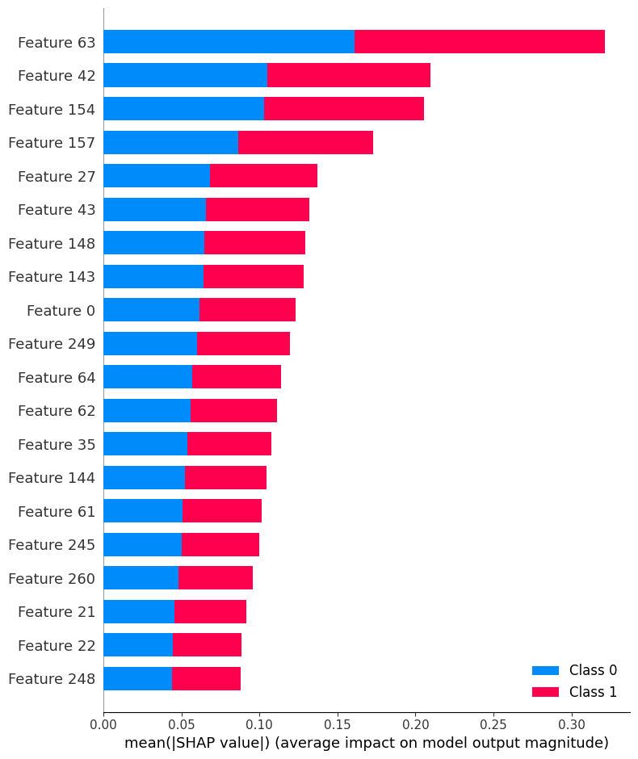

```python
# This code cell uses SHAP values to explain the model.
# First, we import the SHAP library.
import shap

# We create a TreeExplainer object using our trained model.
explainer = shap.TreeExplainer(model)

# We then calculate SHAP values for our test data.
shap_values = explainer.shap_values(X_test)

# Finally, we plot the SHAP values using a bar chart.
shap.summary_plot(shap_values, X_test, plot_type="bar")
```

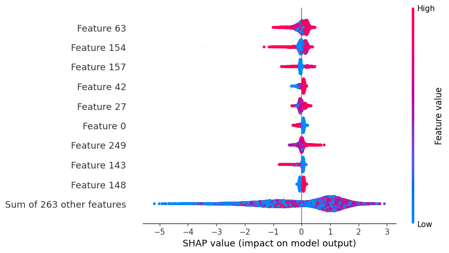

```python
# Use the SHAP library beeswarm plot to show the directionality of features
# With such a large dataset, this step takes around 30 minutes!

explainer = shap.Explainer(model, X_train)
shap_values = explainer(X_train)

# create beeswarm plot
shap.plots.beeswarm(shap_values)
```

The features with greatest mean absolute importance, at the top of the stack, show non-directional importances. For example, for feature 63, high values (pink dots) were found to be associated with both higher and lower likelihood of dropping out.

We can see some evidence of directionality in features associated with participant attrition. For example, features 42 and 148 indicate that larger valued responses (pink dots) are associated with a positive SHAP value (larger likelihood to respond to questionnaire 6), and lower-valued responses (blue dots) are associated with a negative SHAP value (lower likelihood to respond).

Below, we retrieve the names of features with largest importances.

```python
# Print the feature names associated with the largest mean absolute importance values

# Get the column names of the input data
feature_names = X.columns

# Create a DataFrame to hold the SHAP values for each feature
rf_resultX = pd.DataFrame(shap_values.values, columns=feature_names)

# Calculate the mean absolute SHAP value for each feature
vals = np.abs(rf_resultX.values).mean(0)

# Create a DataFrame to hold the feature names and their mean absolute SHAP values
shap_importance = pd.DataFrame(list(zip(feature_names, vals)),
                                  columns=['col_name','feature_importance_vals'])

# Sort the DataFrame by feature importance, from highest to lowest
shap_importance.sort_values(by=['feature_importance_vals'],
                               ascending=False, inplace=True)
# Print the top 10 features
shap_importance.head(10)
```

|  | col_name | feature_importance_vals |
| --- | --- | --- |
| 63 | agelastperiod_yr_q5 | 0.142003 |
| 154 | colnscop_age | 0.104985 |
| 157 | sigmscop_age | 0.082366 |
| 42 | limitd_wlkmile_q5 | 0.079574 |
| 27 | sit_oth_hrs | 0.068268 |
| 0 | marital_status_q5 | 0.066166 |
| 249 | weight_q5 | 0.063191 |
| 143 | mammo_whenlast | 0.062287 |
| 148 | ct_colnscop_no | 0.062170 |
| 62 | agelastperiod_mo_q5 | 0.060120 |